# Raport Praca Domowa 3

Zuzanna Stankiewicz Monika Jarosińska Weronika Dyszkiewicz

2022-05-03

# Wstęp

Celem projektu było zbadanie czy w społeczeństwie występują problemy z odczytywaniem danych z wykresów w zależności od typu użytej wizualizacji (np. wykres kołowy czy słupkowy). Aby dokonać dokładnej analizy przygotowałyśmy 3 eksperymenty dotyczące różnych typów wykresów. Pierwszy dotyczył wykresów kołowych, kołowych 3D oraz słupkowych. Drugi eksperyment miał na celu porównać czytelność dwóch rodzajów wykresów słupkowych. W trzecim eksperymencie sprawdziłyśmy, z wykorzytsaniem 3 par wykresów, czy kolorystyka, inna skala na osiach oraz usunięcie niektórych danych wpłyną na to, jak ankietowani postrzegają. W naszej ankiecie brało udział 35 osób z różnych środowisk.

### Link do ankiety

https://docs.google.com/forms/d/e/1FAIpQLScwUtqAnhV8Wg3yO0DAdm1KrEIIZC-d6fXSRu5ah6s4eVfSIA/viewform?fbclid=IwAR0ZpgqIBzR_zLQfM_kPKez4MJRTSt5XpSVIBwXc-6KoqJxv9uEA_ux61ns

# Eksperyment 1

Celem eksperymentu pierwszego było sprawdzenie jaki rodzaj wykresu jest najprostszy do oszacowywania wartości. W tym celu przedstawiłyśmy ankietowanym trzy wykresy - kołowy, kołowy 3D oraz słupkowy - przedstawiające te same dane i poprosiłyśmy o uszeregowanie rosnąco wartości kategorii.

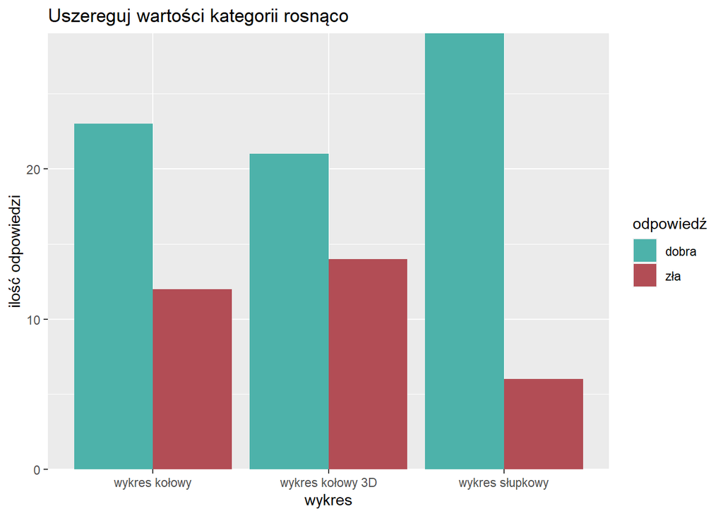

Można zauważyć, że ankietowani w większości odpowiadali poprawnie dla wszystkich trzech wykresów, jednak zdecydowanie najwięcej poprawnych odpowiedzi pojawiło się dla wykresu słupkowego. Najtrudniejszy okazał się wykres kołowy 3D, w którym pojawiło się najwięcej błędów.

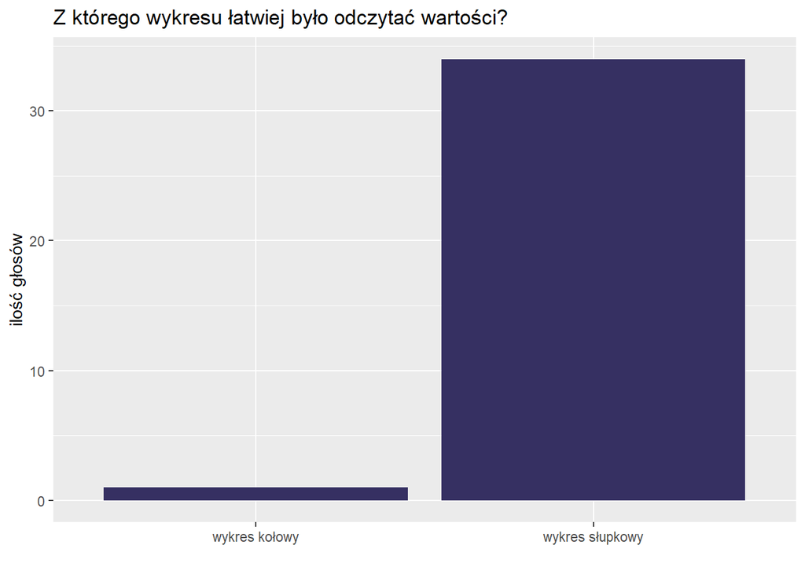

Kolejną częścią eksperymentu było pytanie, z którego wykresu najłatwiej było odczytać wartości. Nie jest zaskoczeniem, że niemal wszyscy wskazali tutaj wykres słupkowy (z wyjątkiem jednej osoby), co wskazuje na to, że mimo iż odczytanie wartości z wykresów kołowych jest dla większości osób możliwe, jest to trudniejsze zadanie niż w przypadku wykresu słupkowego, gdzie jasno widać zależności pomiędzy różnymi kategoriami.

# Eksperyment 2

W drugim eksperymencie naszym celem było porównanie dwóch rodzajów wykresów słupkowych, przedstawiającyh te same dane. Ankietowani zostali poproszeni o odczytanie 3 wartości kolejno z każdego z wykresów. Za odpowiedź poprawną uznawałyśmy, gdy liczba podana przez ankietowanych różniła się o nie więcej niż 1.

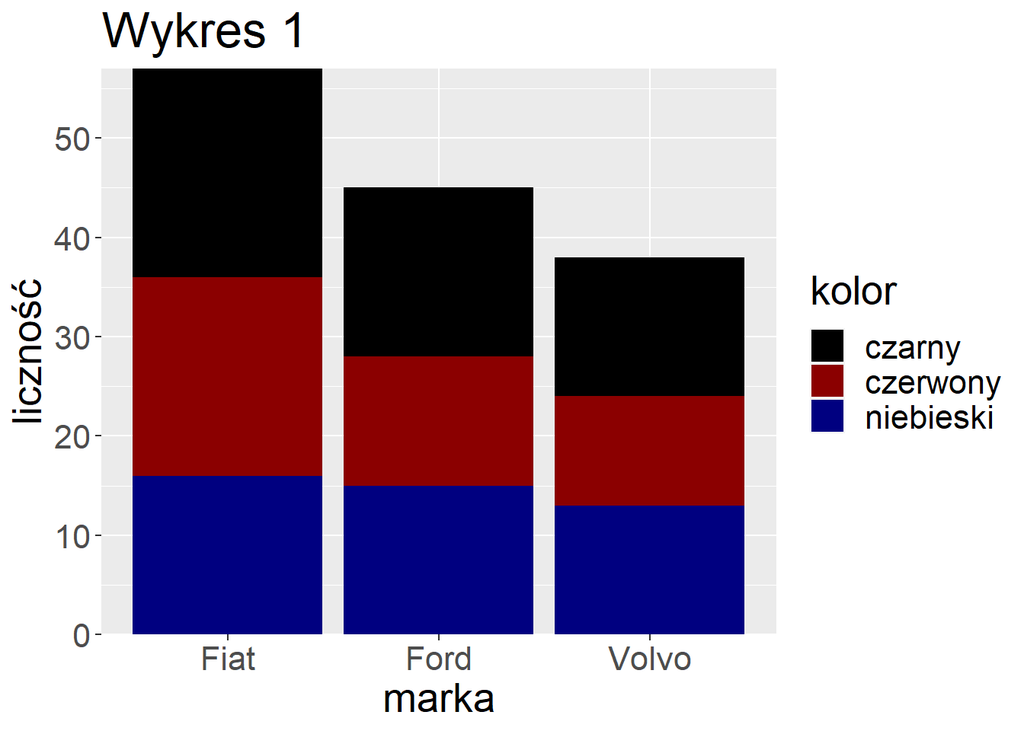

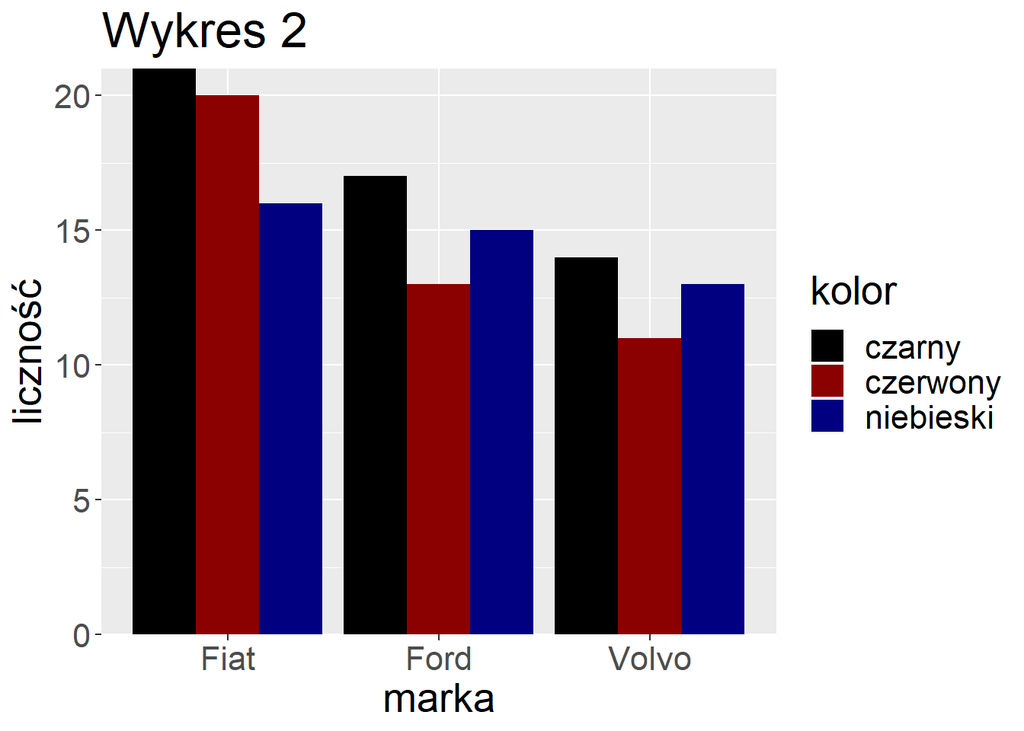

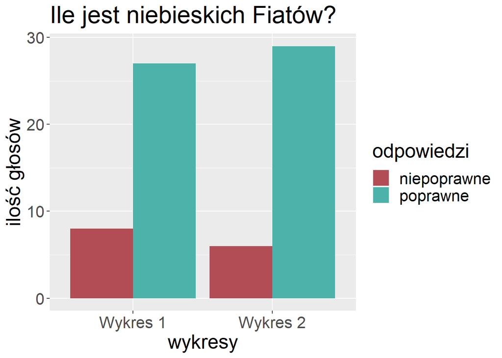

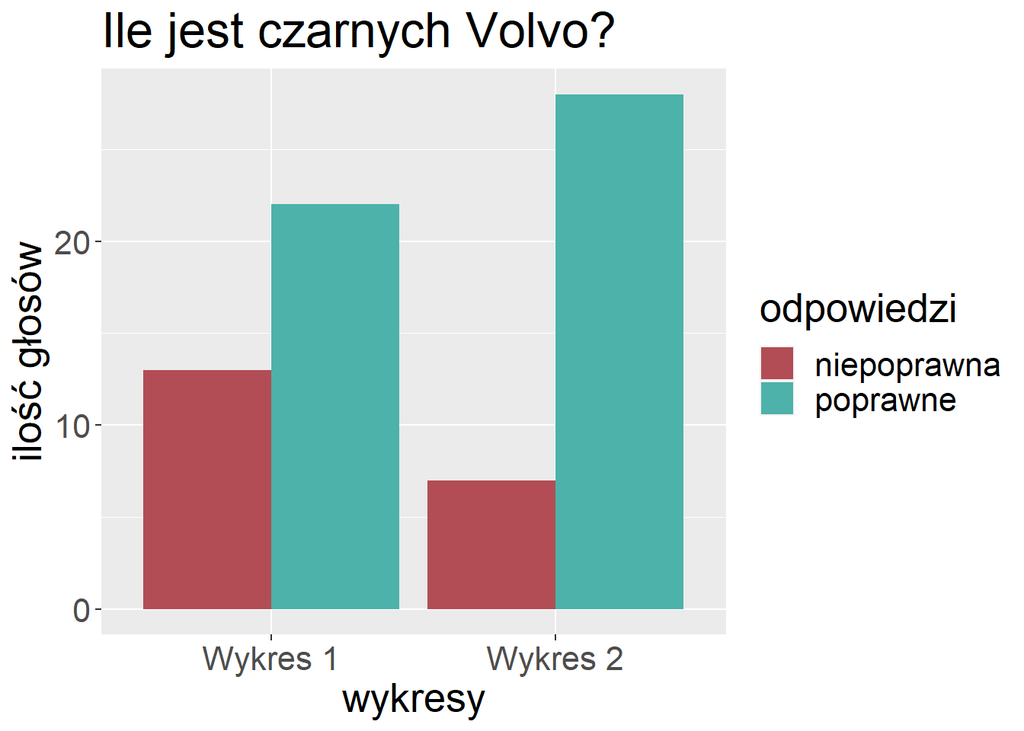

[figure not shown]

Wyniki wskazują, że w przypadku obu wykresów ankietowaniu w większości odpowiadali na pytania poprawnie. Jednak porównując bezpośrednio wykresy 1 i 2 można zauważyć, że więcej odpowiedzi poprawnych jest dla wykresu 2, w przypadku każdego z postawionych pytań.

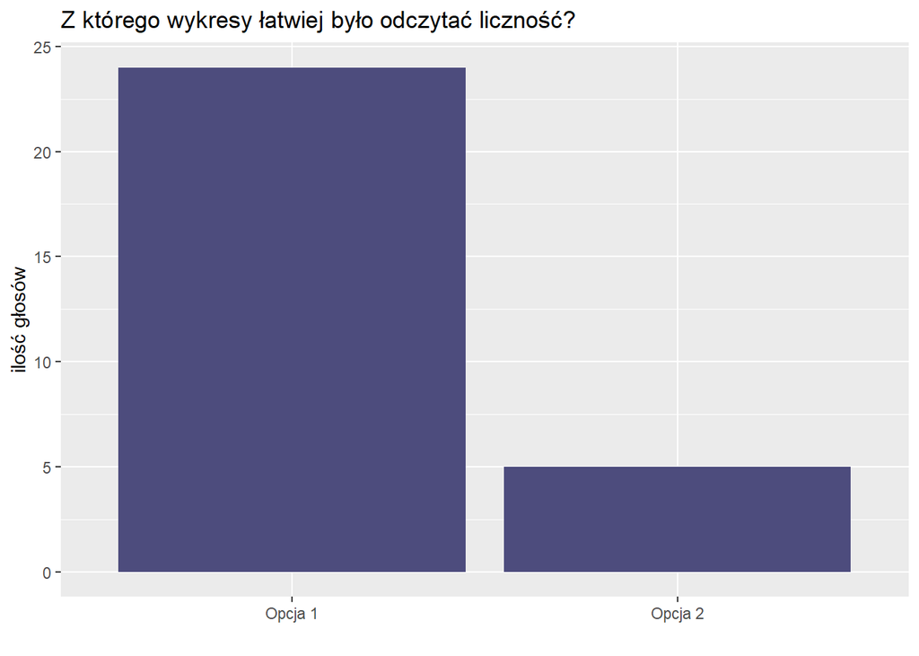

W dalszej części ekspereymentu akietowani zostali poproszenie o wskazanie wykresu z którego łatwiej im było oczytać dane. Zdecydowana większość odpowiadała, że z wykresu 1, pomimo, że częściej zdażały się błędne odpowiedzi, w przypadku odczytywania danych z tego wykresu.

# Eksperyment 3

W ostatnim eksperymencie poprosiłyśmy ankietowanych o porównanie ze sobą trzech par wykresów. Każda para przedstawiała te same dane, jednak na inne sposoby, gdyż dla każdej pary w jednym z wykresów celowo wprowadzono drobne zmiany wizualizacyjne.

### Braki danych

W pierwszej parze na jednym z wykresów na osi x brakowało niektórych danych.

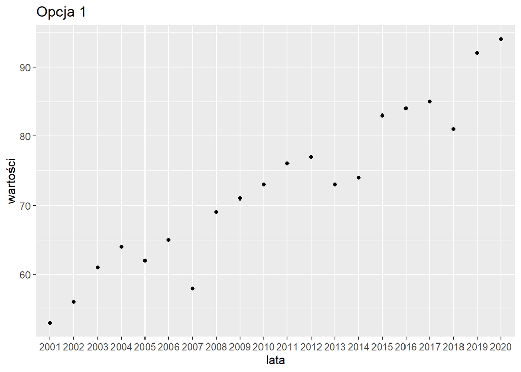

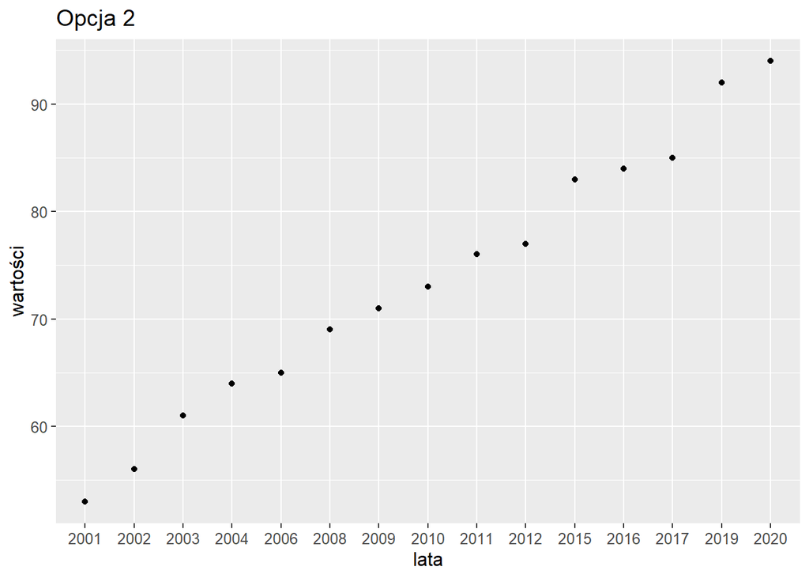

### Wyniki

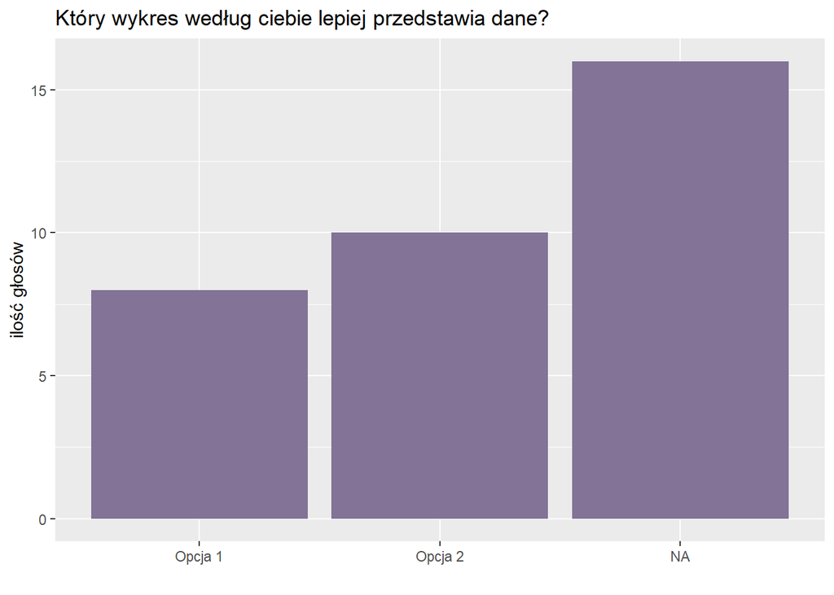

### Skala niezaczynająca się od 0

Kolejna para wykresów różniła się skalą na osi y, mianowicie na jednym z wykresów nie zaczynała się ona od 0.

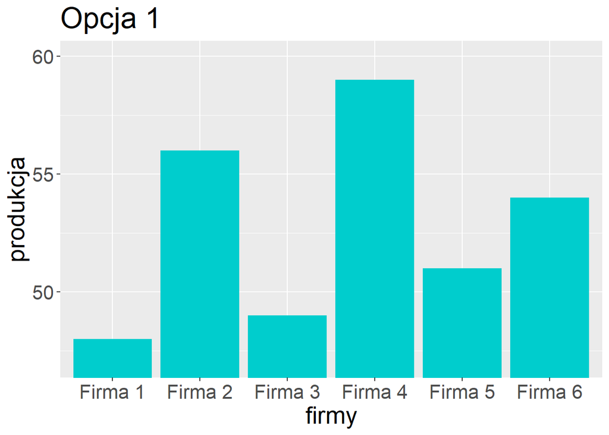

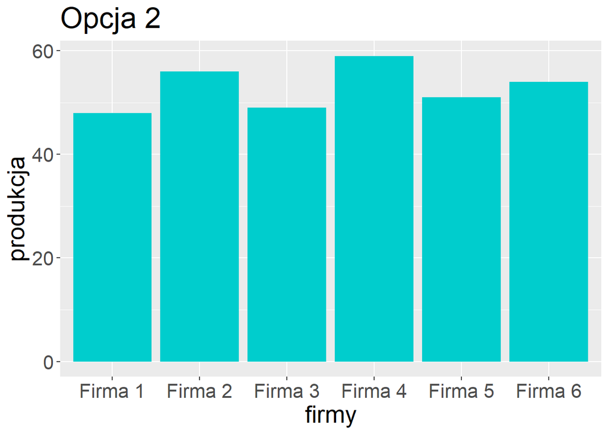

### Wyniki

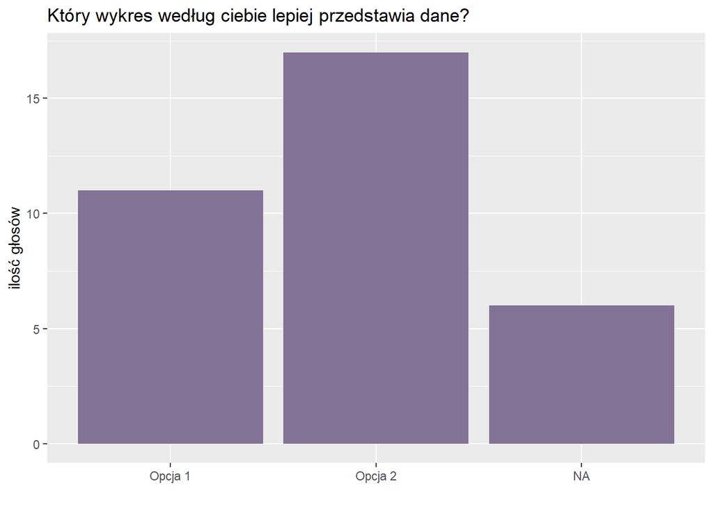

Większość naszych respondentów wybrała opcję drugą, gdzie wykres był poprawny, a Oś Y prawidłowo zaczyna się od zera. 11 osób wybrało opcję pierwszą, gdzie oś Y błędnie zaczyna się od wartości wynoszącej 47. Sześć osób twierdzi, że wykresy nie robią im różnicy.

### Skala kolorystyczna

W trzeciej parze dodano niepotrzebne wypełnienie kolorami kategorii względem wartości.

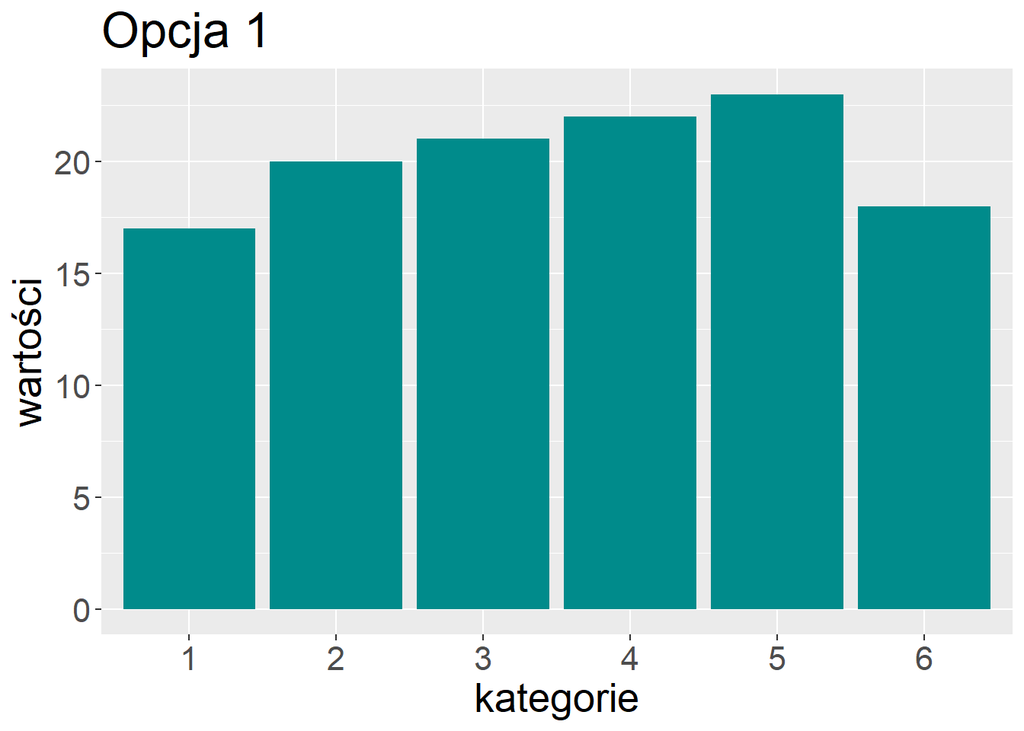

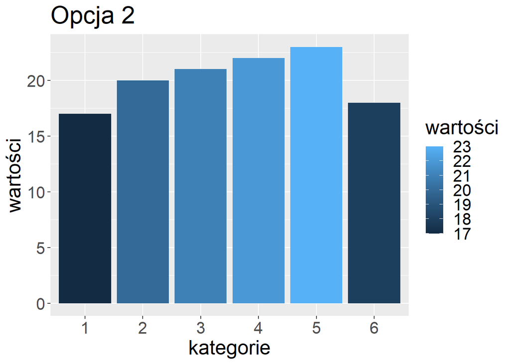

### Wyniki

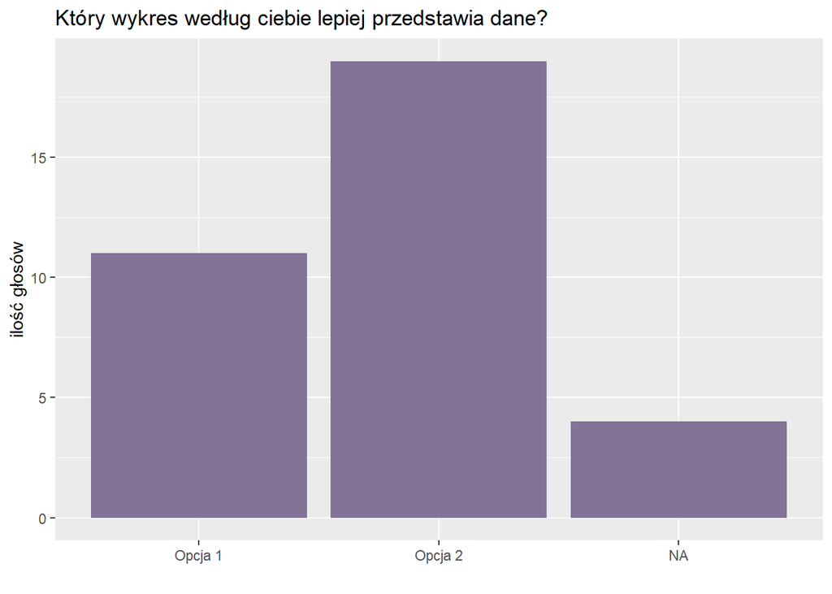

Nasi ankietowani w większości wybierali opcję drugą, gdzie jest więcej kolorów. Jedenaście osób wybrało opcję poprawniejszą, gdzie na tę ilość danych wystarczy jeden kolor oraz cztery osoby uważały, że im nie robi różnicy, który wykres poprawniejszy.

# Podsumowanie